# Video 005 — V-005 analysis and sensitivity

## tl;dr

The frozen 2001→2023 primary comparison has 161 pair-comparable countries and areas. Among 133 with a robust obesity rise, PoU fell robustly in 81, rose robustly in 28 and was directionally indeterminate in 24.

This notebook is an internal scientific artifact. It does not authorize public copy, storyboard, render, site changes, upload or publication.

## Question, hypotheses and scope

**Question:** from 2001 to 2023, as adult obesity rose robustly, did undernourishment more often rise with it or fall?

- H1 requires `p_F > p_R > 0` in the primary endpoint comparison.
- H2 requires the same ordering in every V-004 sensitivity plus independent reproduction.

This is descriptive ecological co-movement, not causal attribution and not a same-people comparison. The hypotheses were data-informed before the source, quality, method and sensitivity contracts were frozen.

```python
from pathlib import Path
import json
import pandas as pd
import matplotlib.pyplot as plt
from IPython.display import display, Markdown

VIDEO = Path("..").resolve()
ANALYTICS = VIDEO / "analytics"
MANIFESTS = VIDEO / "manifests"

plt.rcParams.update({
    "figure.figsize": (11, 6),
    "figure.dpi": 120,
    "font.size": 11,
    "axes.titlesize": 15,
    "axes.edgecolor": "#374151",
    "axes.labelcolor": "#111827",
    "xtick.color": "#374151",
    "ytick.color": "#374151",
    "grid.color": "#d1d5db",
    "grid.alpha": 0.55,
})

annual = pd.read_csv(ANALYTICS / "v005-annual-map-composition.csv")
sensitivity = pd.read_csv(ANALYTICS / "v005-sensitivity-results.csv")
regions = pd.read_csv(ANALYTICS / "v005-region-endpoint-summary.csv")
diagnostics = pd.read_csv(ANALYTICS / "v005-diagnostic-scenarios.csv")
transitions = pd.read_csv(ANALYTICS / "v005-transition-diagnostics.csv")
decisions = json.loads((ANALYTICS / "v005-endpoint-decisions.json").read_text())
validation = json.loads((MANIFESTS / "v005-validation.json").read_text())

assert validation["status"] == "PASS"
assert validation["independentReproduction"] == "PASS"
assert validation["passedCount"] == validation["checkCount"] == 28
assert decisions["h1"]["verdict"] == "SUPPORTED"
assert decisions["h2"]["numericalVerdict"] == "SUPPORTED"
print("Frozen V-005 snapshot loaded; independent reproduction PASS")
```

```
Frozen V-005 snapshot loaded; independent reproduction PASS
```

## Primary result

```python
primary = sensitivity.loc[sensitivity["scenario_id"] == "P0_2001_2023"].iloc[0]
primary_table = pd.DataFrame({
    "State": ["R: PoU robust rise", "F: PoU robust fall", "U: PoU indeterminate"],
    "Countries and areas": [int(primary.R_n), int(primary.F_n), int(primary.U_n)],
    "Conditional share": [primary.p_R, primary.p_F, primary.p_U],
})
primary_table["Conditional share"] = primary_table["Conditional share"].map(lambda x: f"{x:.1%}")
display(primary_table)
display(Markdown(
    f"**H1: SUPPORTED.** Conditional n={int(primary.conditional_n)}; "
    f"p_F−p_R={primary.gap_F_minus_R_pp:.1f} percentage points."
))
```

|  | State | Countries and areas | Conditional share |
| --- | --- | --- | --- |
| 0 | R: PoU robust rise | 28 | 21.1% |
| 1 | F: PoU robust fall | 81 | 60.9% |
| 2 | U: PoU indeterminate | 24 | 18.0% |

**H1: SUPPORTED.** Conditional n=133; p_F−p_R=39.8 percentage points.

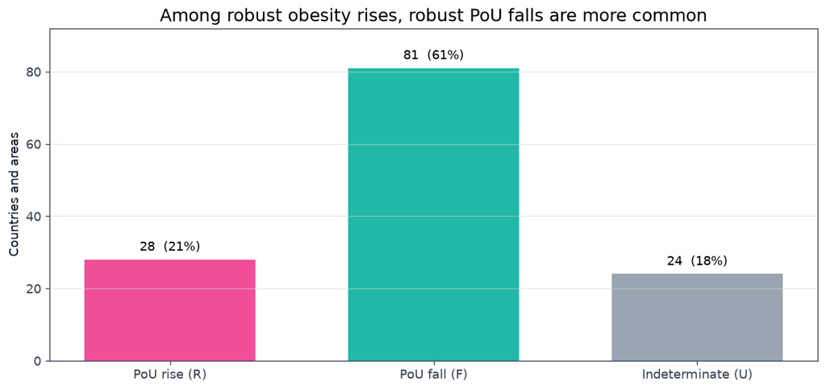

```python
fig, ax = plt.subplots(figsize=(10, 4.8))
labels = ["PoU rise (R)", "PoU fall (F)", "Indeterminate (U)"]
values = [int(primary.R_n), int(primary.F_n), int(primary.U_n)]
colors = ["#F04E98", "#22B8A7", "#9AA5B1"]
bars = ax.bar(labels, values, color=colors, width=0.65)
ax.bar_label(bars, labels=[f"{v}  ({v/int(primary.conditional_n):.0%})" for v in values], padding=5, fontsize=11)
ax.set_title("Among robust obesity rises, robust PoU falls are more common")
ax.set_ylabel("Countries and areas")
ax.set_ylim(0, 92)
ax.grid(axis="y")
fig.tight_layout()
plt.show()
```

The conditional denominator excludes O, the 28 endpoint-comparable entities whose obesity interval did not establish a robust rise. Public map A combines O with U for visual simplicity, but H1/H2 keep them separate.

## Evolution relative to the 2001 baseline

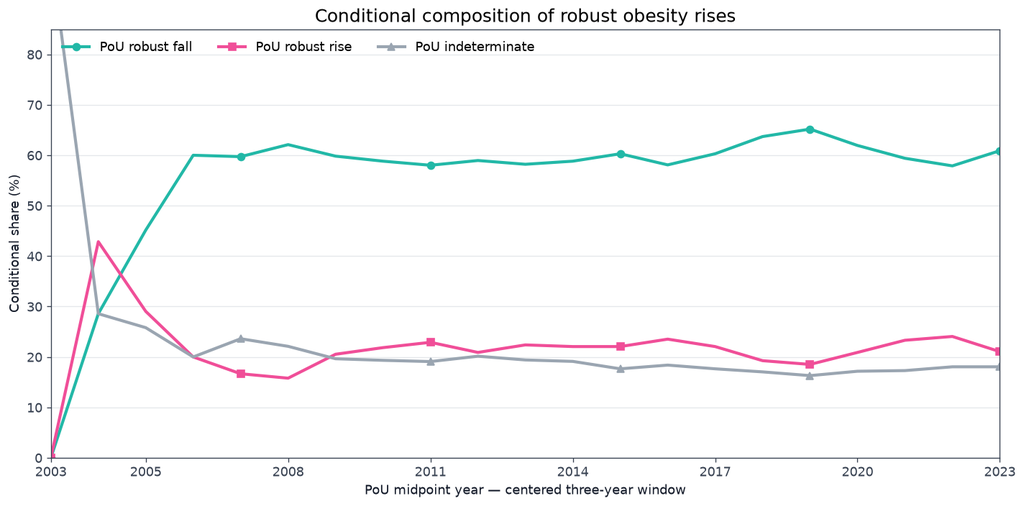

```python
usable = annual.dropna(subset=["p_R", "p_F", "p_U"]).copy()
fig, ax = plt.subplots(figsize=(12, 6))
for field, label, color, marker in [
    ("p_F", "PoU robust fall", "#22B8A7", "o"),
    ("p_R", "PoU robust rise", "#F04E98", "s"),
    ("p_U", "PoU indeterminate", "#9AA5B1", "^"),
]:
    ax.plot(usable.midpoint_year, usable[field] * 100, label=label, color=color,
            linewidth=2.5, marker=marker, markevery=4)
ax.set_title("Conditional composition of robust obesity rises")
ax.set_xlabel("PoU midpoint year — centered three-year window")
ax.set_ylabel("Conditional share (%)")
ax.set_xlim(2003, 2023)
ax.set_ylim(0, 85)
ax.set_xticks([2003, 2005, 2008, 2011, 2014, 2017, 2020, 2023])
ax.grid(axis="y")
ax.legend(frameon=False, ncol=3, loc="upper left")
fig.tight_layout()
plt.show()
```

Adjacent points are not independent annual observations: each PoU midpoint window overlaps the next by two source years. The line is a moving-window description, not evidence of annual shocks.

## Registered sensitivity audit

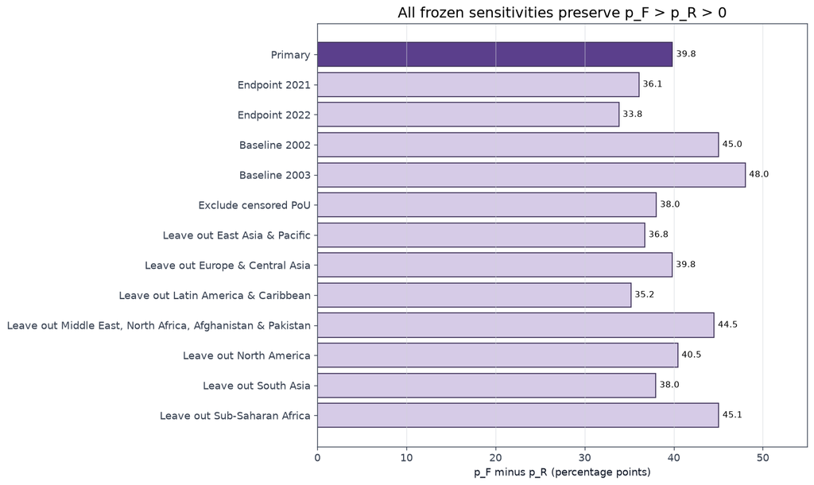

|  | scenario_id | pair_comparable_n | conditional_n | R_n | F_n | U_n | gap_F_minus_R_pp | scenario_status |
| --- | --- | --- | --- | --- | --- | --- | --- | --- |
| 0 | P0_2001_2023 | 161 | 133 | 28 | 81 | 24 | 39.8 | SUPPORTED |
| 1 | E1_2001_2021 | 162 | 133 | 31 | 79 | 23 | 36.1 | SUPPORTED |
| 2 | E2_2001_2022 | 162 | 133 | 32 | 77 | 24 | 33.8 | SUPPORTED |
| 3 | B1_2002_2023 | 161 | 131 | 26 | 85 | 20 | 45.0 | SUPPORTED |
| 4 | B2_2003_2023 | 161 | 127 | 24 | 85 | 18 | 48.0 | SUPPORTED |
| 5 | C1_2001_2023_NO_POU_CENSOR | 99 | 92 | 28 | 63 | 1 | 38.0 | SUPPORTED |
| 6 | L1_2001_2023_EXCLUDE_REGION_EAST_ASIA_PACIFIC | 141 | 117 | 27 | 70 | 20 | 36.8 | SUPPORTED |
| 7 | L1_2001_2023_EXCLUDE_REGION_EUROPE_CENTRAL_ASIA | 113 | 103 | 27 | 68 | 8 | 39.8 | SUPPORTED |
| 8 | L1_2001_2023_EXCLUDE_REGION_LATIN_AMERICA_CARI... | 135 | 108 | 23 | 61 | 24 | 35.2 | SUPPORTED |
| 9 | L1_2001_2023_EXCLUDE_REGION_MIDDLE_EAST_NORTH_... | 142 | 119 | 21 | 74 | 24 | 44.5 | SUPPORTED |
| 10 | L1_2001_2023_EXCLUDE_REGION_NORTH_AMERICA | 159 | 131 | 28 | 81 | 22 | 40.5 | SUPPORTED |
| 11 | L1_2001_2023_EXCLUDE_REGION_SOUTH_ASIA | 157 | 129 | 28 | 77 | 24 | 38.0 | SUPPORTED |
| 12 | L1_2001_2023_EXCLUDE_REGION_SUB_SAHARAN_AFRICA | 119 | 91 | 14 | 55 | 22 | 45.1 | SUPPORTED |

```python
short_labels = {
    "P0_2001_2023": "Primary",
    "E1_2001_2021": "Endpoint 2021",
    "E2_2001_2022": "Endpoint 2022",
    "B1_2002_2023": "Baseline 2002",
    "B2_2003_2023": "Baseline 2003",
    "C1_2001_2023_NO_POU_CENSOR": "Exclude censored PoU",
}
plot = sensitivity.copy()
plot["label"] = plot.scenario_id.map(short_labels).fillna(
    plot.region_excluded.map(lambda x: f"Leave out {x}" if isinstance(x, str) else x)
)
fig, ax = plt.subplots(figsize=(12, 7.2))
colors = ["#5B3F8C" if family == "primary" else "#D6CBE7" for family in plot.family]
bars = ax.barh(plot.label, plot.gap_F_minus_R_pp, color=colors, edgecolor="#3D3157")
ax.bar_label(bars, labels=[f"{v:.1f}" for v in plot.gap_F_minus_R_pp], padding=4, fontsize=9)
ax.axvline(0, color="#111827", linewidth=1)
ax.invert_yaxis()
ax.set_title("All frozen sensitivities preserve p_F > p_R > 0")
ax.set_xlabel("p_F minus p_R (percentage points)")
ax.set_xlim(0, 55)
ax.grid(axis="x")
fig.tight_layout()
plt.show()
display(sensitivity[[
    "scenario_id", "pair_comparable_n", "conditional_n", "R_n", "F_n", "U_n",
    "gap_F_minus_R_pp", "scenario_status"
]].round({"gap_F_minus_R_pp": 1}))
```

## Regional heterogeneity

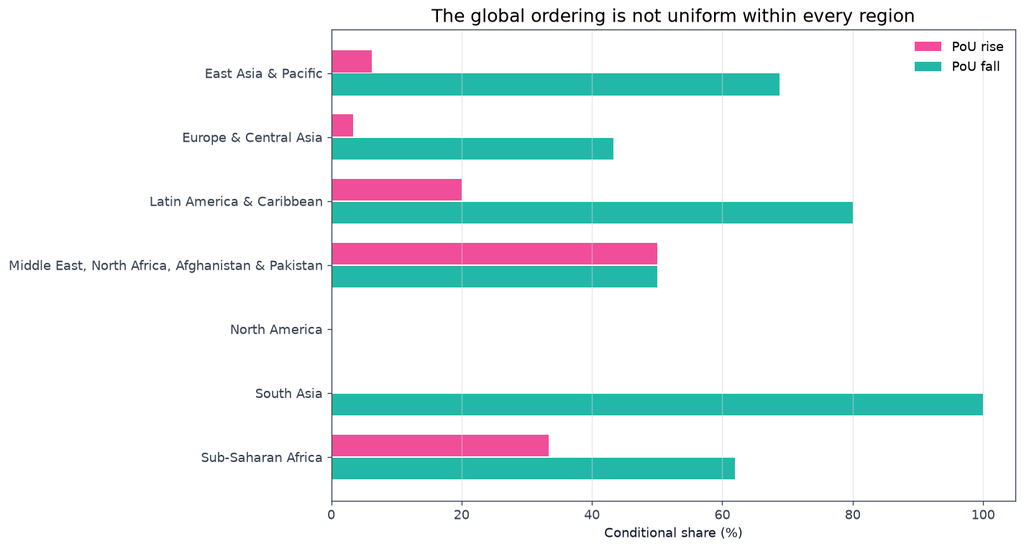

|  | region | conditional_n | R_n | F_n | U_n | gap_F_minus_R_pp |
| --- | --- | --- | --- | --- | --- | --- |
| 0 | East Asia & Pacific | 16 | 1 | 11 | 4 | 62.5 |
| 1 | Europe & Central Asia | 30 | 1 | 13 | 16 | 40.0 |
| 2 | Latin America & Caribbean | 25 | 5 | 20 | 0 | 60.0 |
| 3 | Middle East, North Africa, Afghanistan & Pakistan | 14 | 7 | 7 | 0 | 0.0 |
| 4 | North America | 2 | 0 | 0 | 2 | 0.0 |
| 5 | South Asia | 4 | 0 | 4 | 0 | 100.0 |
| 6 | Sub-Saharan Africa | 42 | 14 | 26 | 2 | 28.6 |

```python
regional = regions.copy()
regional["p_R_pct"] = regional.p_R * 100
regional["p_F_pct"] = regional.p_F * 100
fig, ax = plt.subplots(figsize=(12, 6.5))
y = range(len(regional))
ax.barh([i - 0.18 for i in y], regional.p_R_pct, height=0.34, color="#F04E98", label="PoU rise")
ax.barh([i + 0.18 for i in y], regional.p_F_pct, height=0.34, color="#22B8A7", label="PoU fall")
ax.set_yticks(list(y), regional.region)
ax.invert_yaxis()
ax.set_title("The global ordering is not uniform within every region")
ax.set_xlabel("Conditional share (%)")
ax.set_xlim(0, 105)
ax.grid(axis="x")
ax.legend(frameon=False)
fig.tight_layout()
plt.show()
display(regional[["region", "conditional_n", "R_n", "F_n", "U_n", "gap_F_minus_R_pp"]].round(1))
```

These are diagnostics, not regional hypothesis tests or rankings. North America has only two conditional entities, both U; MENA, Afghanistan & Pakistan has a 7–7 tie. The global leave-one-region-out result nevertheless stays supported for every frozen exclusion.

## Modeling and presentation diagnostics

```python
display(diagnostics[[
    "scenario_id", "pair_comparable_n", "conditional_n", "R_n", "F_n", "U_n",
    "O_n", "gap_F_minus_R_pp", "scenario_status"
]].round({"gap_F_minus_R_pp": 1}))

largest = transitions.sort_values("state_changed_n", ascending=False).iloc[0]
endpoint = annual.loc[annual.midpoint_year == 2023].iloc[0]
display(pd.DataFrame([
    ("Endpoint public map: R", int(endpoint.R_n)),
    ("Endpoint public map: F", int(endpoint.F_n)),
    ("Endpoint public map: A", int(endpoint.A_n)),
    ("Mapped endpoint entities", int(endpoint.mapped_comparable_n)),
    ("Off-map endpoint entities", int(endpoint.off_map_comparable_n)),
    ("Largest adjacent public-state turnover", int(largest.state_changed_n)),
], columns=["Diagnostic", "Observed"]))
```

|  | scenario_id | pair_comparable_n | conditional_n | R_n | F_n | U_n | O_n | gap_F_minus_R_pp | scenario_status |
| --- | --- | --- | --- | --- | --- | --- | --- | --- | --- |
| 0 | D0_PRIMARY_INTERVAL | 161 | 133 | 28 | 81 | 24 | 28 | 39.8 | SUPPORTED |
| 1 | D1_POINT_OBESITY | 161 | 158 | 31 | 93 | 34 | 3 | 39.2 | SUPPORTED |
| 2 | D2_POU_CENSORED_MIDPOINT_1_25 | 161 | 133 | 28 | 81 | 24 | 28 | 39.8 | SUPPORTED |
| 3 | D3_POU_CENSORED_EXACT_2_5_BIAS | 161 | 133 | 28 | 81 | 24 | 28 | 39.8 | SUPPORTED |

|  | Diagnostic | Observed |
| --- | --- | --- |
| 0 | Endpoint public map: R | 28 |
| 1 | Endpoint public map: F | 81 |
| 2 | Endpoint public map: A | 52 |
| 3 | Mapped endpoint entities | 149 |
| 4 | Off-map endpoint entities | 12 |
| 5 | Largest adjacent public-state turnover | 22 |

Point-only obesity estimates would classify more entities as robust rises than the interval method. The two censored-PoU point diagnostics happen to match the primary endpoint counts, but this does not justify treating a reported threshold as an exact value. The frozen interval method remains authoritative.

## Decision and limitations

V-006 must translate these findings into the final answer and limitations hierarchy. Nothing in this notebook authorizes public copy or publication.